# USL_AllLife_Bank_Project_X

## Context

- AllLife Bank wants to focus on its credit card customer base in the next financial year. They have been advised by their marketing research team, that the penetration in the market can be improved. Based on this input, the Marketing team proposes to run personalized campaigns to target new customers as well as upsell to existing customers. Another insight from the market research was that the customers perceive the support services of the bank poorly. Based on this, the Operations team wants to upgrade the service delivery model, to ensure that customer queries are resolved faster. Head of Marketing and Head of Delivery both decide to reach out to the Data Science team for help

## Objective

- To identify different segments in the existing customer based on their spending patterns
- To identify past interaction with the bank using K-Means and Agglomerative Heirachichal Clustering Algorithms
- To profer recommendations to the bank on how best to target and market these customers along with the best customer service offering perculiar to them.

## Data Description

- The data provided is of various customers of a bank and their financial attributes like credit limit, the total number of credit cards the customer has, and different channels through which customers have contacted the bank for any queries (including visiting the bank, online and through a call center).

### Data Dictionary

- Sl_No: Primary key of the records
- Customer Key: Customer identification number
- Average Credit Limit: Average credit limit of each customer for all credit cards
- Total credit cards: Total number of credit cards possessed by the customer
- Total visits bank: Total number of Visits that customer made (yearly) personally to the bank
- Total visits online: Total number of visits or online logins made by the customer (yearly)
- Total calls made: Total number of calls made by the customer to the bank or its customer service department (yearly)

### Index

- Overview of the dataset
- Data Description
- Exploratory Data Analysis
- K-Means Clustering
- Cluster Profiling - K-Means
- Hierarchichal Clustering
- Cluster Profiling - Hierarchichal Clustering
- Customer Profile - Ward Linkage
- Cluster Algorithm Comparison
- Business Recommendations

### Importing necessary libraries

```python
# this will help in making the Python code more structured automatically (good coding practice)
#%load_ext nb_black

# Libraries to help with reading and manipulating data
import numpy as np
import pandas as pd

# Removes the limit for the number of displayed columns
pd.set_option("display.max_columns", None)
# Sets the limit for the number of displayed rows
pd.set_option("display.max_rows", 200)

# Libraries to help with data visualization
import matplotlib.pyplot as plt
import seaborn as sns

# to scale the data using z-score
from sklearn.preprocessing import StandardScaler

# to compute distances
from scipy.spatial.distance import cdist
from scipy.spatial.distance import pdist

# to perform k-means clustering and compute silhouette scores
from sklearn.cluster import KMeans
from sklearn.metrics import silhouette_score

# to perform hierarchical clustering, compute cophenetic correlation, and create dendrograms
from sklearn.cluster import AgglomerativeClustering
from scipy.cluster.hierarchy import dendrogram, linkage, cophenet

# to install the yellowbrick package for elbow visualization
#! pip install yellowbrick

# to visualize the elbow curve and silhouette scores
from yellowbrick.cluster import KElbowVisualizer, SilhouetteVisualizer

# To Suppress Warnings
import warnings
warnings.filterwarnings('ignore')
```

### Overview of Dataset

```python
# loading the dataset
data = pd.read_excel("Credit Card Customer Data.xlsx")
```

```python
data.head()
```

|  | Sl_No | Customer Key | Avg_Credit_Limit | Total_Credit_Cards | Total_visits_bank | Total_visits_online | Total_calls_made |
| --- | --- | --- | --- | --- | --- | --- | --- |
| 0 | 1 | 87073 | 100000 | 2 | 1 | 1 | 0 |
| 1 | 2 | 38414 | 50000 | 3 | 0 | 10 | 9 |
| 2 | 3 | 17341 | 50000 | 7 | 1 | 3 | 4 |
| 3 | 4 | 40496 | 30000 | 5 | 1 | 1 | 4 |
| 4 | 5 | 47437 | 100000 | 6 | 0 | 12 | 3 |

```python
# copying the data to another variable to avoid any changes to original data
df = data.copy()
```

```python
# checking the head of the data
df.head()
```

|  | Sl_No | Customer Key | Avg_Credit_Limit | Total_Credit_Cards | Total_visits_bank | Total_visits_online | Total_calls_made |
| --- | --- | --- | --- | --- | --- | --- | --- |
| 0 | 1 | 87073 | 100000 | 2 | 1 | 1 | 0 |
| 1 | 2 | 38414 | 50000 | 3 | 0 | 10 | 9 |
| 2 | 3 | 17341 | 50000 | 7 | 1 | 3 | 4 |
| 3 | 4 | 40496 | 30000 | 5 | 1 | 1 | 4 |
| 4 | 5 | 47437 | 100000 | 6 | 0 | 12 | 3 |

- We can see the data makes sense. Zero(0) values in Total_visits_bank and Total_calls_made is indeed possible.
- We can also notice the huge values of the Avg_Credit_Limit which will introduce some bias if not scaled prior to Clustering

```python
# fixing column names
df.columns = [c.replace(" ", "_") for c in df.columns]
```

```python
df.shape
```

```
(660, 7)
```

- The dataset has 660 rows and 7 columns

```python
# viewing a random sample of the dataset
df.sample(n=10, random_state=1)
```

|  | Sl_No | Customer_Key | Avg_Credit_Limit | Total_Credit_Cards | Total_visits_bank | Total_visits_online | Total_calls_made |
| --- | --- | --- | --- | --- | --- | --- | --- |
| 547 | 548 | 38125 | 26000 | 4 | 5 | 2 | 4 |
| 353 | 354 | 94437 | 9000 | 5 | 4 | 1 | 3 |
| 499 | 500 | 65825 | 68000 | 6 | 4 | 2 | 2 |
| 173 | 174 | 38410 | 9000 | 2 | 1 | 5 | 8 |
| 241 | 242 | 81878 | 10000 | 4 | 5 | 1 | 3 |
| 341 | 342 | 70779 | 18000 | 4 | 3 | 2 | 0 |
| 647 | 648 | 79953 | 183000 | 9 | 0 | 9 | 2 |
| 218 | 219 | 28208 | 19000 | 3 | 1 | 5 | 7 |
| 120 | 121 | 16577 | 10000 | 4 | 2 | 4 | 6 |
| 134 | 135 | 31256 | 13000 | 4 | 1 | 5 | 7 |

- We can see the data makes sense. Zero(0) values in Total_visits_bank and Total_calls_made is indeed possible.

```python
# dropping the SI_No and the Customer_Key columns as they are not relevant for our analysis
df.drop(['Sl_No','Customer_Key'], axis=1, inplace=True)
```

```python
#checking changes
df.head()
```

|  | Avg_Credit_Limit | Total_Credit_Cards | Total_visits_bank | Total_visits_online | Total_calls_made |
| --- | --- | --- | --- | --- | --- |
| 0 | 100000 | 2 | 1 | 1 | 0 |
| 1 | 50000 | 3 | 0 | 10 | 9 |
| 2 | 50000 | 7 | 1 | 3 | 4 |
| 3 | 30000 | 5 | 1 | 1 | 4 |
| 4 | 100000 | 6 | 0 | 12 | 3 |

```python
df.info()
```

```
<class 'pandas.core.frame.DataFrame'>
RangeIndex: 660 entries, 0 to 659
Data columns (total 5 columns):
 #   Column               Non-Null Count  Dtype
---  ------               --------------  -----
 0   Avg_Credit_Limit     660 non-null    int64
 1   Total_Credit_Cards   660 non-null    int64
 2   Total_visits_bank    660 non-null    int64
 3   Total_visits_online  660 non-null    int64
 4   Total_calls_made     660 non-null    int64
dtypes: int64(5)
memory usage: 25.9 KB
```

**Observations**

- All the features are of Int64 data type
- As we can see there are no missing values across features.

```python
# let's check for duplicate observations
df.duplicated().sum()
```

```
11
```

- There are 11 duplicate values in the dataset

```python
# removing duplicate values from the data
df = df[(~df.duplicated())].copy()
```

### Data Description

```python
df.describe().T
```

|  | count | mean | std | min | 25% | 50% | 75% | max |
| --- | --- | --- | --- | --- | --- | --- | --- | --- |
| Avg_Credit_Limit | 649.0 | 34878.274268 | 37813.736638 | 3000.0 | 11000.0 | 18000.0 | 49000.0 | 200000.0 |
| Total_Credit_Cards | 649.0 | 4.708783 | 2.173763 | 1.0 | 3.0 | 5.0 | 6.0 | 10.0 |
| Total_visits_bank | 649.0 | 2.397535 | 1.625148 | 0.0 | 1.0 | 2.0 | 4.0 | 5.0 |
| Total_visits_online | 649.0 | 2.624037 | 2.952888 | 0.0 | 1.0 | 2.0 | 4.0 | 15.0 |
| Total_calls_made | 649.0 | 3.590139 | 2.877911 | 0.0 | 1.0 | 3.0 | 5.0 | 10.0 |

**Observations**

- The mean Avg_Credit_Limit is 34878 with 75% of the distribution having a cap of 49000 or less. We can expect outliers here considering the range
- The average Total_Credit_cards stands at approximately 5 with 75% of the customers having 6 credit cards or less
- The maximum Total_visits_bank is 5 with a mean of 2. Some customers did not visit the bank at all.
- Similarly, the mean Total_visits_online is approx. 3 with the maximum at 15. There are Outliers here considering the range
- 50% of the Total_calls_made by customers were 3 or less with the maximum of 10.

```python
# checking for missing values
df.isna().sum()
```

```
Avg_Credit_Limit       0
Total_Credit_Cards     0
Total_visits_bank      0
Total_visits_online    0
Total_calls_made       0
dtype: int64
```

- There are no missing values in our data

## Exploratory Data Analysis ( EDA )

### Univariate Analysis

```python
# updating the seaborn library
#sns.__version__
#!pip install seaborn==0.11.0
```

```python
# While doing uni-variate analysis of numerical variables we want to study their central tendency
# and dispersion.
# Let us write a function that will help us create boxplot and histogram for any input numerical
# variable.
# This function takes the numerical column as the input and returns the boxplots
# and histograms for the variable.
# Let us see if this help us write faster and cleaner code.
def histogram_boxplot(feature, figsize=(15,10), bins = None):
    """ Boxplot and histogram combined
    feature: 1-d feature array
    figsize: size of fig (default (9,8))
    bins: number of bins (default None / auto)
    """
    f2, (ax_box2, ax_hist2) = plt.subplots(nrows = 2, # Number of rows of the subplot grid= 2
                                           sharex = True, # x-axis will be shared among all subplots
                                           gridspec_kw = {"height_ratios": (.25, .75)},
                                           figsize = figsize
                                           ) # creating the 2 subplots
    sns.boxplot(feature, ax=ax_box2, showmeans=True, color='violet') # boxplot will be created and a star will indicate the mean value of the column
    sns.displot(feature, kde=F, ax=ax_hist2, bins=bins,palette="winter") if bins else sns.distplot(feature, kde=False, ax=ax_hist2) # For histogram
    ax_hist2.axvline(np.mean(feature), color='green', linestyle='--') # Add mean to the histogram
    ax_hist2.axvline(np.median(feature), color='black', linestyle='-') # Add median to the histogram
```

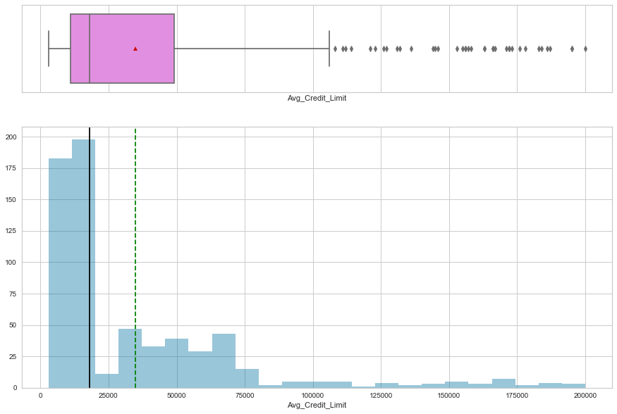

```python
histogram_boxplot(df['Avg_Credit_Limit'])
plt.savefig('Plt_ACL.png')
plt.show()
```

**Observations**

- As can be inferred, there is an obvious presence of outliers as expected, hence the right skew nature
- The mean Avg_Credit_limit (34878) is greater than the median (18000)
- The outliers are quite close and may ultimately impact or form clusters of their own. The upper outliers start at 105000 with the maximum at 200,000

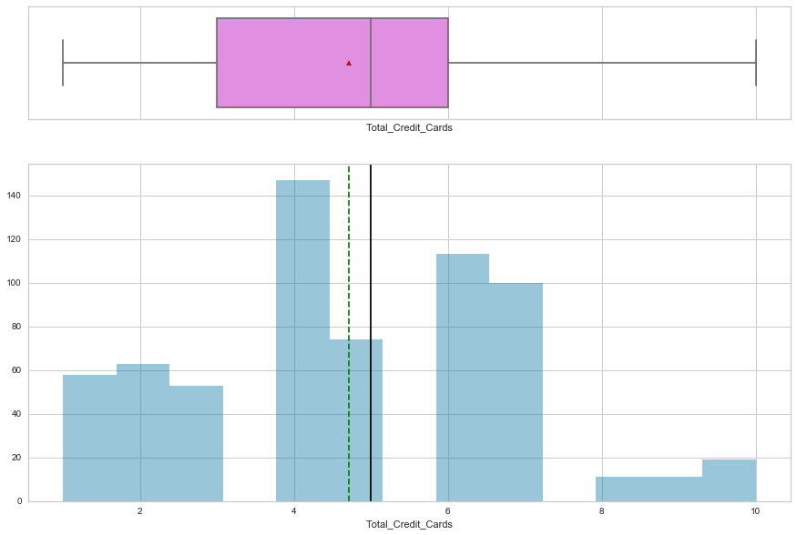

```python
histogram_boxplot(df['Total_Credit_Cards'])
plt.savefig('Plt_TCC.png')
plt.show()
```

### Observation

- The average Total_Credit_Cards is lower than the Mean position. Hence we have a Left Skew distribution
- The are no presence of outliers
- 50% 0f the distribution has att least 5 credit cards with the maximum at 10 cards
- This speaks to a highly geared customer distribution

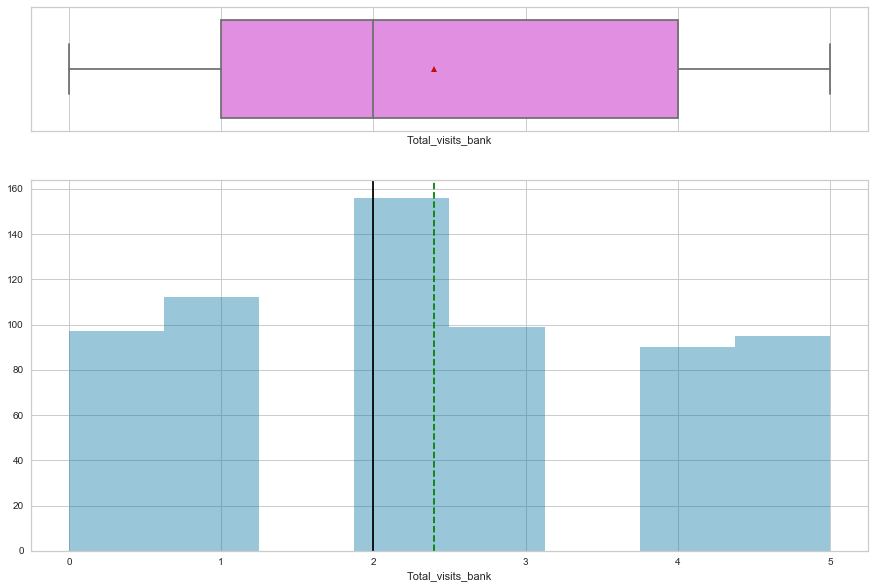

```python
histogram_boxplot(df['Total_visits_bank'])
plt.savefig('Plt_TvB.png')
plt.show()
```

### Observation

- There are no presence of outliers here
- The mean of 2.4 is greater than the median of 2.
- 75% 0f the distribution made at least 4 visits or less to the bank with the most being at 2

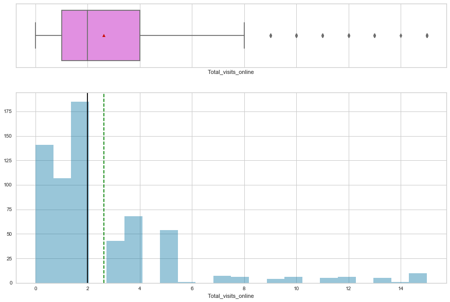

```python
histogram_boxplot(df['Total_visits_online'])
plt.savefig('Plt_TvO.png')
plt.show()
```

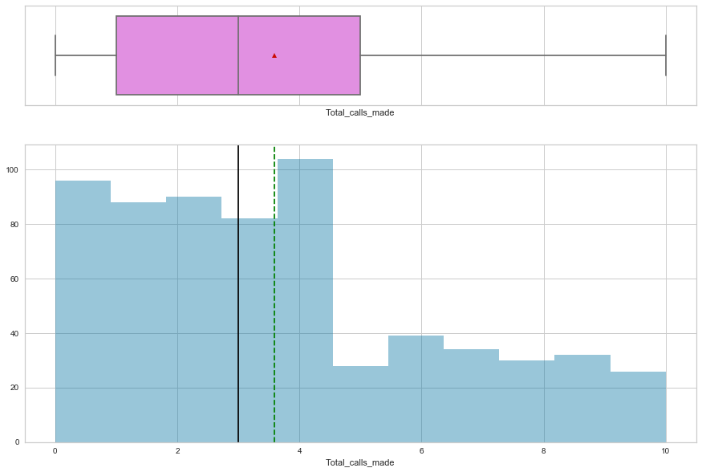

```python
histogram_boxplot(df['Total_calls_made'])
plt.savefig('Plt_TCM.png')
plt.show()
```

```python
# function to create labeled barplots


def labeled_barplot(data, feature, perc=False, n=None):
    """
    Barplot with percentage at the top

    data: dataframe
    feature: dataframe column
    perc: whether to display percentages instead of count (default is False)
    n: displays the top n category levels (default is None, i.e., display all levels)
    """

    total = len(data[feature])  # length of the column
    count = data[feature].nunique()
    if n is None:
        plt.figure(figsize=(count + 1, 5))
    else:
        plt.figure(figsize=(n + 1, 5))

    plt.xticks(rotation=90, fontsize=15)
    ax = sns.countplot(
        data=data,
        x=feature,
        palette="Paired",
        order=data[feature].value_counts().index[:n].sort_values(),
    )

    for p in ax.patches:
        if perc == True:
            label = "{:.1f}%".format(
                100 * p.get_height() / total
            )  # percentage of each class of the category
        else:
            label = p.get_height()  # count of each level of the category

        x = p.get_x() + p.get_width() / 2  # width of the plot
        y = p.get_height()  # height of the plot

        ax.annotate(
            label,
            (x, y),
            ha="center",
            va="center",
            size=12,
            xytext=(0, 5),
            textcoords="offset points",
        )  # annotate the percentage

    plt.show()  # show the plot
```

[figure not shown]

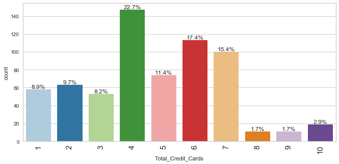

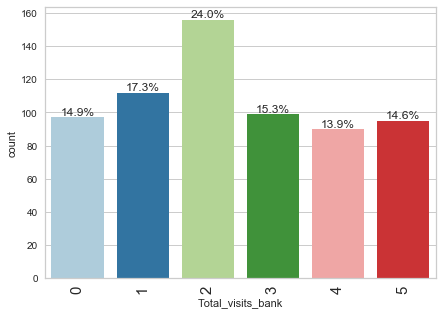

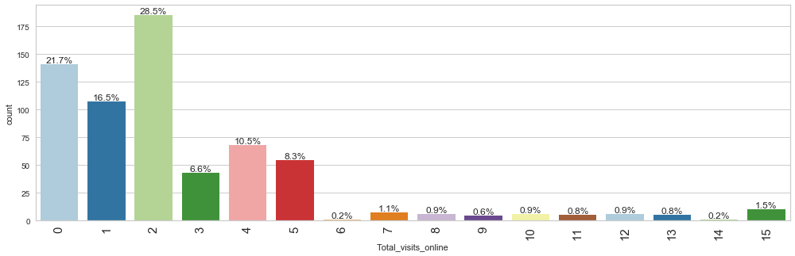

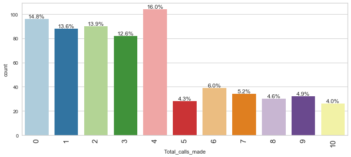

```python
# selecting numerical columns
num_col = df.select_dtypes(include=np.number).columns.tolist()

for item in num_col:
    labeled_barplot(df, item, perc=True)
```

**Observations**

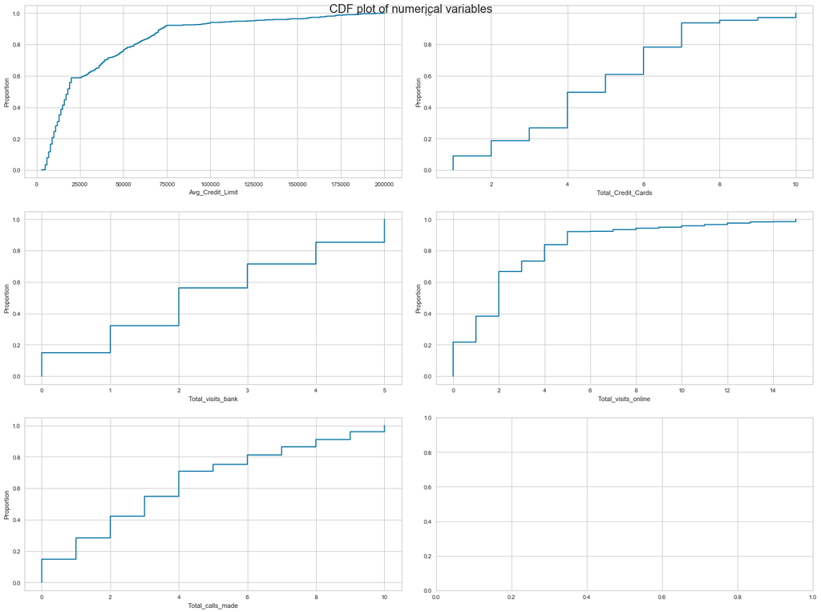

```python
# cdf plot of numerical variables
fig, axes = plt.subplots(3, 2, figsize=(20, 15))
fig.suptitle("CDF plot of numerical variables", fontsize=20)
counter = 0
for ii in range(3):
    sns.ecdfplot(ax=axes[ii][0], x=df[num_col[counter]])
    counter = counter + 1
    if counter != 5:
        sns.ecdfplot(ax=axes[ii][1], x=df[num_col[counter]])
        counter = counter + 1
    else:
        pass

fig.tight_layout(pad=2.0)
```

- The CDF Plot of the variables reinforces the insights from the bar plots above

### Bivariate Analsysis

**Let's check for correlations.**

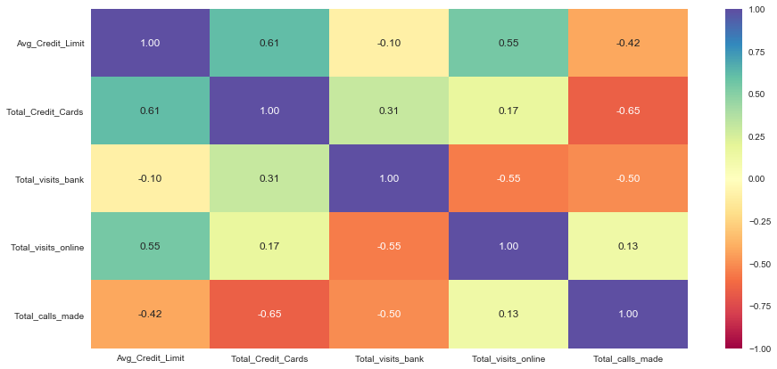

```python
plt.figure(figsize=(15, 7))
sns.heatmap(df[num_col].corr(), annot=True, vmin=-1, vmax=1, fmt=".2f", cmap="Spectral")
plt.show()
```

**Observation**

- There is a fairly strong correlation between Total_visits_online and Avg_Credit_Limit
- There is quite a strong correlation between Avg_Credit_Limit and Total_Credit_Cards
- This speaks to a likely trend of viability for more credit as customers acquire more cards

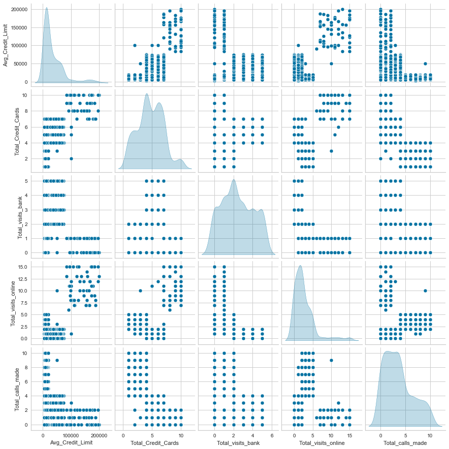

```python
sns.pairplot(data=df[num_col], diag_kind="kde")
plt.show()
```

## K-Means Clustering

```python
# Scaling the data set before clustering
scaler = StandardScaler()
subset = df[num_col].copy()
subset_scaled = scaler.fit_transform(subset)
```

```python
# Creating a dataframe from the scaled data
subset_scaled_df = pd.DataFrame(subset_scaled, columns=subset.columns)
subset_scaled_df.head()
```

|  | Avg_Credit_Limit | Total_Credit_Cards | Total_visits_bank | Total_visits_online | Total_calls_made |
| --- | --- | --- | --- | --- | --- |
| 0 | 1.723499 | -1.247087 | -0.860606 | -0.550407 | -1.248443 |
| 1 | 0.400209 | -0.786701 | -1.476410 | 2.499808 | 1.881237 |
| 2 | 0.400209 | 1.054846 | -0.860606 | 0.127419 | 0.142526 |
| 3 | -0.129107 | 0.134072 | -0.860606 | -0.550407 | 0.142526 |
| 4 | 1.723499 | 0.594459 | -1.476410 | 3.177634 | -0.205216 |

```
Number of Clusters: 1 	Average Distortion: 2.007896349270688
Number of Clusters: 2 	Average Distortion: 1.4576197022077824
Number of Clusters: 3 	Average Distortion: 1.1434401208195093
Number of Clusters: 4 	Average Distortion: 1.0435538595477063
Number of Clusters: 5 	Average Distortion: 0.9880528362621137
Number of Clusters: 6 	Average Distortion: 0.9405296177116815
Number of Clusters: 7 	Average Distortion: 0.9073962602676325
Number of Clusters: 8 	Average Distortion: 0.889925875132963
```

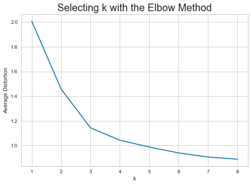

```python
clusters = range(1, 9)
meanDistortions = []

for k in clusters:
    model = KMeans(n_clusters=k)
    model.fit(subset_scaled_df)
    prediction = model.predict(subset_scaled_df)
    distortion = (
        sum(
            np.min(cdist(subset_scaled_df, model.cluster_centers_, "euclidean"), axis=1)
        )
        / subset_scaled_df.shape[0]
    )

    meanDistortions.append(distortion)

    print("Number of Clusters:", k, "\tAverage Distortion:", distortion)

plt.plot(clusters, meanDistortions, "bx-")
plt.xlabel("k")
plt.ylabel("Average Distortion")
plt.title("Selecting k with the Elbow Method", fontsize=20)
```

**Let's check the silhouette scores.**

```
For n_clusters = 2, silhouette score is 0.41800025566689647
For n_clusters = 3, silhouette score is 0.516281010855363
For n_clusters = 4, silhouette score is 0.3570238219413198
For n_clusters = 5, silhouette score is 0.2730908848204728
For n_clusters = 6, silhouette score is 0.25673640107222434
For n_clusters = 7, silhouette score is 0.24818145458400265
For n_clusters = 8, silhouette score is 0.22572446383362413
For n_clusters = 9, silhouette score is 0.22719466242403996
```

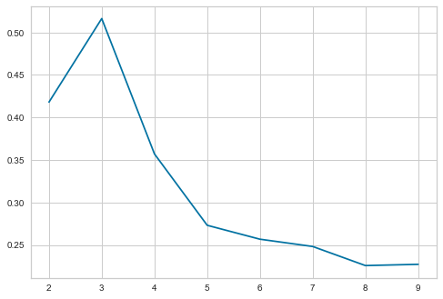

```python
sil_score = []
cluster_list = list(range(2, 10))
for n_clusters in cluster_list:
    clusterer = KMeans(n_clusters=n_clusters, random_state=10)
    preds = clusterer.fit_predict((subset_scaled_df))
    score = silhouette_score(subset_scaled_df, preds)
    sil_score.append(score)
    print("For n_clusters = {}, silhouette score is {}".format(n_clusters, score))

plt.plot(cluster_list, sil_score) # -1 TO 0 TO  1
```

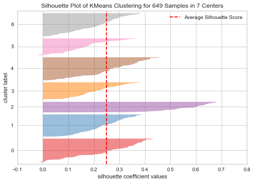

```python
# finding optimal no. of clusters with silhouette coefficients
visualizer = SilhouetteVisualizer(KMeans(7, random_state=1))
visualizer.fit(subset_scaled_df)
visualizer.show()
```

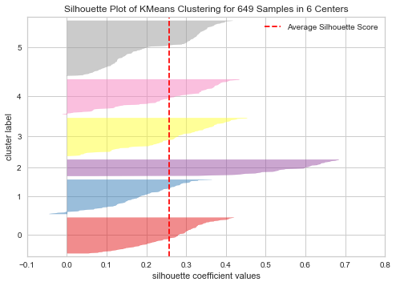

```python
# finding optimal no. of clusters with silhouette coefficients
visualizer = SilhouetteVisualizer(KMeans(6, random_state=1))
visualizer.fit(subset_scaled_df)
visualizer.show()
```

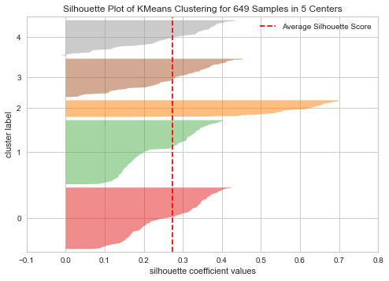

```python
# finding optimal no. of clusters with silhouette coefficients
visualizer = SilhouetteVisualizer(KMeans(5, random_state=1))
visualizer.fit(subset_scaled_df)
visualizer.show()
```

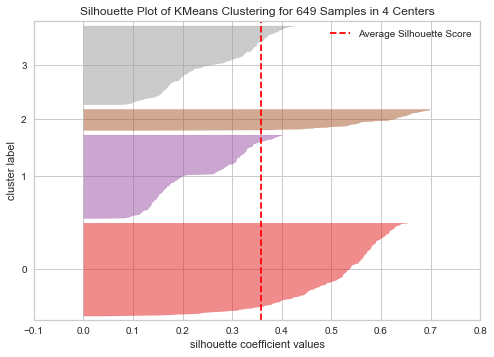

```python
# finding optimal no. of clusters with silhouette coefficients
visualizer = SilhouetteVisualizer(KMeans(4, random_state=1))
visualizer.fit(subset_scaled_df)
visualizer.show()
```

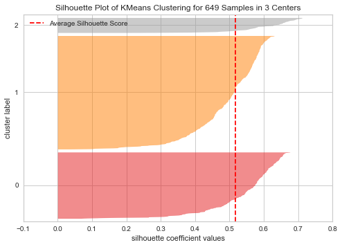

```python
# finding optimal no. of clusters with silhouette coefficients
visualizer = SilhouetteVisualizer(KMeans(3, random_state=1))
visualizer.fit(subset_scaled_df)
visualizer.show()
```

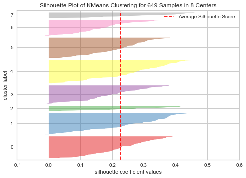

```python
# finding optimal no. of clusters with silhouette coefficients
visualizer = SilhouetteVisualizer(KMeans(8, random_state=1))
visualizer.fit(subset_scaled_df)
visualizer.show()
```

**Let's take 4 as the appropriate no. of clusters as the silhouette score is high enough and there is knick at 4 in the elbow curve.**

### Cluster Profiling - K-Means Clustering

```python
kmeans = KMeans(n_clusters=4, random_state=0)
kmeans.fit(subset_scaled_df)
```

```
KMeans(n_clusters=4, random_state=0)
```

```python
# adding kmeans cluster labels to the original dataframe
df["K_means_segments"] = kmeans.labels_
```

```python
KM_cluster_profile = df.groupby("K_means_segments").mean()
```

```python
KM_cluster_profile["customers_in_each_segment"] = (df.groupby("K_means_segments")["Avg_Credit_Limit"].count().values)
```

```python
# let's display cluster profiles
KM_cluster_profile.style.highlight_max(color="lightgreen", axis=0)
```

| K_means_segments | Avg_Credit_Limit | Total_Credit_Cards | Total_visits_bank | Total_visits_online | Total_calls_made | customers_in_each_segment |
| --- | --- | --- | --- | --- | --- | --- |
| 0 | 35857.142857 | 5.525510 | 2.479592 | 0.974490 | 2.056122 | 196 |
| 1 | 31832.432432 | 5.481081 | 4.513514 | 1.005405 | 1.940541 | 185 |
| 2 | 12233.944954 | 2.394495 | 0.940367 | 3.582569 | 6.944954 | 218 |
| 3 | 141040.000000 | 8.740000 | 0.600000 | 10.900000 | 1.080000 | 50 |

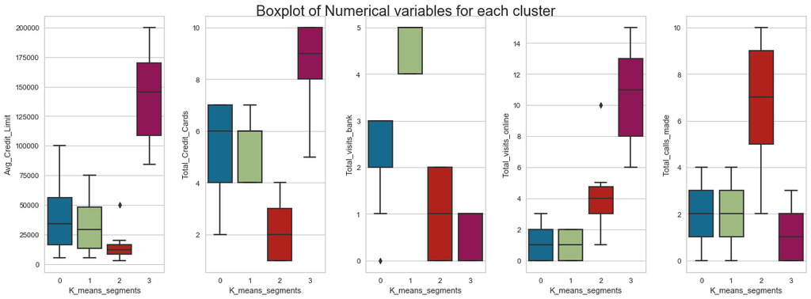

```python
fig, axes = plt.subplots(1, 5, figsize=(16, 6))
fig.suptitle("Boxplot of Numerical variables for each cluster", fontsize=20)
counter = 0
for ii in range(5):
    sns.boxplot(ax=axes[ii], y=df[num_col[counter]], x=df["K_means_segments"])
    counter = counter + 1

fig.tight_layout(pad=2.0)
```

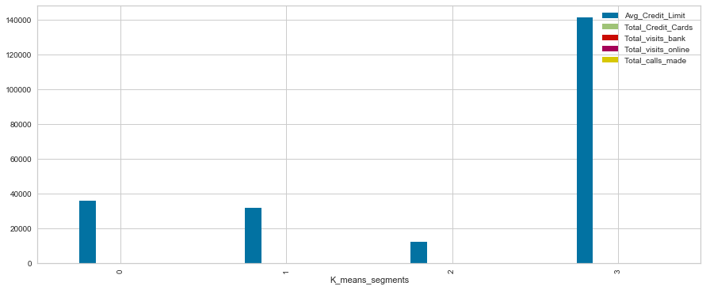

```python
#plotting the bar charts
df.groupby("K_means_segments").mean().plot.bar(figsize=(15, 6))
```

### Insights

- **Clusters 0**:
  - There are 196 customers in this cluster
  - The Avg_Credit_limit for this cluster is roughly 36,000 which is way above the median limit
  - Customers in this cluster have approximately 6 credit cards
  - 2 visits were made by these customers to the bank in a year
  - Roughly 1 visit was made online by customers in this cluster in a year
  - Customers in this cluster made 2 calls to the customer service of the bank in a year
- **Cluster 1**:
  - There are 185 customers in this cluster
  - The Avg_Credit_limit for this cluster is roughly 32,000 which is way above the median limit
  - Customers in this cluster have approximately 5 credit cards
  - 5 visits were made by these customers to the bank in a year
  - 1 visit was made online by customers in this cluster in a year
  - Customers in this cluster made 2 calls to the customer service of the bank in a year
- **Cluster 2**:
  - There are 218 customers in this cluster
  - The Avg_Credit_limit for this cluster is roughly 12,500 which is way below the median limit
  - Customers in this cluster have approximately 2 credit cards
  - 1 visit was made by these customers to the bank in a year
  - Roughly 4 visits were made online by customers in this cluster in a year
  - Customers in this cluster made approx. 7 calls to the customer service of the bank in a year
- **Cluster 3**:
  - There are 50 customers in this cluster
  - The Avg_Credit_limit for this cluster is roughly 141,000 which is way above the 75th percentile limit
  - Customers in this cluster have approximately 9 credit cards
  - 1 visit was made by these customers to the bank in a year
  - Roughly 11 visit were made online by customers in this cluster in a year
  - Customers in this cluster made 1 call to the customer service of the bank in a year

## Hierarchical Clustering

```python
# list of distance metrics
distance_metrics = ["euclidean", "chebyshev", "mahalanobis", "cityblock"]

# list of linkage methods
linkage_methods = ["single", "complete", "average", "weighted"]

high_cophenet_corr = 0
high_dm_lm = [0, 0]

for dm in distance_metrics:
    for lm in linkage_methods:
        Z = linkage(subset_scaled_df, metric=dm, method=lm)
        c, coph_dists = cophenet(Z, pdist(subset_scaled_df))
        print(
            "Cophenetic correlation for {} distance and {} linkage is {}.".format(dm.capitalize(), lm, c)
        )
        if high_cophenet_corr < c:
            high_cophenet_corr = c
            high_dm_lm[0] = dm
            high_dm_lm[1] = lm
```

```
Cophenetic correlation for Euclidean distance and single linkage is 0.7395135051413775.
Cophenetic correlation for Euclidean distance and complete linkage is 0.8794736468795109.
Cophenetic correlation for Euclidean distance and average linkage is 0.8974425535306298.
Cophenetic correlation for Euclidean distance and weighted linkage is 0.8551098644586315.
Cophenetic correlation for Chebyshev distance and single linkage is 0.7379112982920528.
Cophenetic correlation for Chebyshev distance and complete linkage is 0.8578617029322211.
Cophenetic correlation for Chebyshev distance and average linkage is 0.8960370054789858.
Cophenetic correlation for Chebyshev distance and weighted linkage is 0.893309534644998.
Cophenetic correlation for Mahalanobis distance and single linkage is 0.7054746377393306.
Cophenetic correlation for Mahalanobis distance and complete linkage is 0.6513369047977693.
Cophenetic correlation for Mahalanobis distance and average linkage is 0.8325707682057718.
Cophenetic correlation for Mahalanobis distance and weighted linkage is 0.7902500571553815.
Cophenetic correlation for Cityblock distance and single linkage is 0.7253931237436752.
Cophenetic correlation for Cityblock distance and complete linkage is 0.8741048470104825.
Cophenetic correlation for Cityblock distance and average linkage is 0.8960391624288154.
Cophenetic correlation for Cityblock distance and weighted linkage is 0.8804995247359442.
```

```python
# printing the combination of distance metric and linkage method with the highest cophenetic correlation
print(
    "Highest cophenetic correlation is {}, which is obtained with {} distance and {} linkage.".format(
        high_cophenet_corr, high_dm_lm[0].capitalize(), high_dm_lm[1]
    )
)
```

```
Highest cophenetic correlation is 0.8974425535306298, which is obtained with Euclidean distance and average linkage.
```

**Let's explore different linkage methods with Euclidean distance only**

```python
# list of linkage methods
linkage_methods = ["single", "complete", "average", "centroid", "ward", "weighted"]

high_cophenet_corr = 0
high_dm_lm = [0, 0]

for lm in linkage_methods:
    Z = linkage(subset_scaled_df, metric="euclidean", method=lm)
    c, coph_dists = cophenet(Z, pdist(subset_scaled_df))
    print("Cophenetic correlation for {} linkage is {}.".format(lm, c))
    if high_cophenet_corr < c:
        high_cophenet_corr = c
        high_dm_lm[0] = "euclidean"
        high_dm_lm[1] = lm
```

```
Cophenetic correlation for single linkage is 0.7395135051413775.
Cophenetic correlation for complete linkage is 0.8794736468795109.
Cophenetic correlation for average linkage is 0.8974425535306298.
Cophenetic correlation for centroid linkage is 0.894471288720818.
Cophenetic correlation for ward linkage is 0.7425813590948763.
Cophenetic correlation for weighted linkage is 0.8551098644586315.
```

```python
# printing the combination of distance metric and linkage method with the highest cophenetic correlation
print(
    "Highest cophenetic correlation is {}, which is obtained with {} linkage.".format(
        high_cophenet_corr, high_dm_lm[1]
    )
)
```

```
Highest cophenetic correlation is 0.8974425535306298, which is obtained with average linkage.
```

**We see that the cophenetic correlation is maximum with Euclidean distance and average linkage.**

**Let's see the dendrograms for the different linkage methods.**

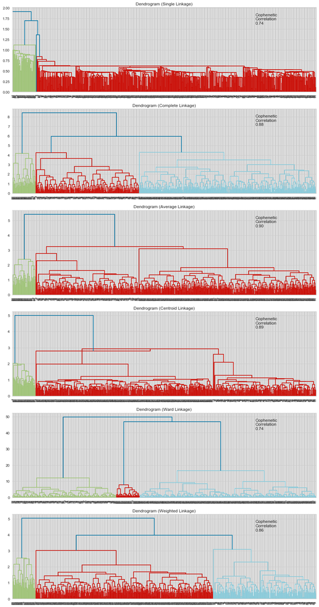

```python
# list of linkage methods
linkage_methods = ["single", "complete", "average", "centroid", "ward", "weighted"]

# lists to save results of cophenetic correlation calculation
compare_cols = ["Linkage", "Cophenetic Coefficient"]

# to create a subplot image
fig, axs = plt.subplots(len(linkage_methods), 1, figsize=(15, 30))

# We will enumerate through the list of linkage methods above
# For each linkage method, we will plot the dendrogram and calculate the cophenetic correlation
for i, method in enumerate(linkage_methods):
    Z = linkage(subset_scaled_df, metric="euclidean", method=method)

    dendrogram(Z, ax=axs[i])
    axs[i].set_title(f"Dendrogram ({method.capitalize()} Linkage)")

    coph_corr, coph_dist = cophenet(Z, pdist(subset_scaled_df))
    axs[i].annotate(
        f"Cophenetic\nCorrelation\n{coph_corr:0.2f}",
        (0.80, 0.80),
        xycoords="axes fraction",
    )
```

**Observations**

- The cophenetic correlation is highest for average and centroid linkage methods.
- We will move ahead with average linkage.
- 6 appears to be the appropriate number of clusters from the dendrogram for average linkage.

### Cluster Profiling - Hierachichal Clustering

```python
HCmodel = AgglomerativeClustering(n_clusters=6, affinity="euclidean", linkage="average")
HCmodel.fit(subset_scaled_df)
```

```
AgglomerativeClustering(linkage='average', n_clusters=6)
```

```python
df1 = subset
```

```python
subset_scaled_df["HC_Clusters"] = HCmodel.labels_
df1["HC_Clusters"] = HCmodel.labels_
```

```python
HC_cluster_profile = df1.groupby("HC_Clusters").mean()
```

```python
HC_cluster_profile["count_in_each_segments"] = (
    df1.groupby("HC_Clusters")["Avg_Credit_Limit"].count().values
)
```

```python
#let's display cluster profiles
HC_cluster_profile.style.highlight_max(color="lightgreen", axis=0)
```

| HC_Clusters | Avg_Credit_Limit | Total_Credit_Cards | Total_visits_bank | Total_visits_online | Total_calls_made | count_in_each_segments |
| --- | --- | --- | --- | --- | --- | --- |
| 0 | 12091.324201 | 2.401826 | 0.945205 | 3.538813 | 6.894977 | 219 |
| 1 | 138388.888889 | 8.555556 | 0.444444 | 14.000000 | 1.055556 | 18 |
| 2 | 142531.250000 | 8.843750 | 0.687500 | 9.156250 | 1.093750 | 32 |
| 3 | 100000.000000 | 2.000000 | 1.000000 | 1.000000 | 0.000000 | 1 |
| 4 | 50000.000000 | 3.000000 | 0.000000 | 10.000000 | 9.000000 | 1 |
| 5 | 33825.396825 | 5.523810 | 3.486772 | 0.984127 | 2.002646 | 378 |

**Let us try using Ward linkage as it has more distinct and separated clusters (as seen from it's dendrogram before). 5 appears to be the appropriate number of clusters from the dendrogram for Ward linkage.**

```python
HCmodel = AgglomerativeClustering(n_clusters=5, affinity="euclidean", linkage="ward")
HCmodel.fit(subset_scaled_df)
```

```
AgglomerativeClustering(n_clusters=5)
```

```python
subset_scaled_df["HC_Clusters"] = HCmodel.labels_
df1["HC_Clusters"] = HCmodel.labels_
```

### Customer Profile - Ward Linkage

```python
cluster_profile = df1.groupby("HC_Clusters").mean()
```

```python
cluster_profile["count_in_each_segments"] = (
    df1.groupby("HC_Clusters")["Avg_Credit_Limit"].count().values
)
```

```python
# let's display cluster profiles
cluster_profile.style.highlight_max(color="lightgreen", axis=0)
```

| HC_Clusters | Avg_Credit_Limit | Total_Credit_Cards | Total_visits_bank | Total_visits_online | Total_calls_made | count_in_each_segments |
| --- | --- | --- | --- | --- | --- | --- |
| 0 | 37561.855670 | 5.634021 | 2.515464 | 1.025773 | 2.159794 | 194 |
| 1 | 30370.967742 | 5.376344 | 4.467742 | 0.989247 | 1.865591 | 186 |
| 2 | 141040.000000 | 8.740000 | 0.600000 | 10.900000 | 1.080000 | 50 |
| 3 | 12178.217822 | 2.198020 | 0.861386 | 3.643564 | 8.623762 | 101 |
| 4 | 12016.949153 | 2.576271 | 1.016949 | 3.449153 | 5.415254 | 118 |

**Now the clusters seem to have more variability.**

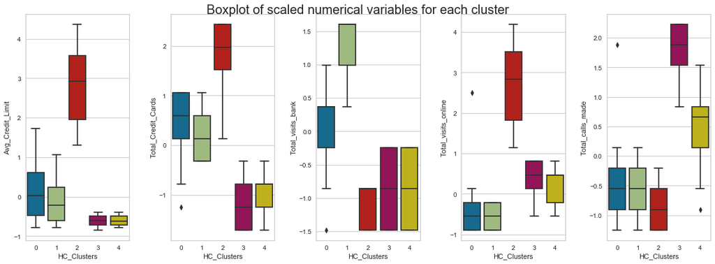

```python
fig, axes = plt.subplots(1, 5, figsize=(16, 6))
fig.suptitle("Boxplot of scaled numerical variables for each cluster", fontsize=20)
counter = 0
for ii in range(5):
    sns.boxplot(
        ax=axes[ii],
        y=subset_scaled_df[num_col[counter]],
        x=subset_scaled_df["HC_Clusters"],
    )
    counter = counter + 1

fig.tight_layout(pad=2.0)
```

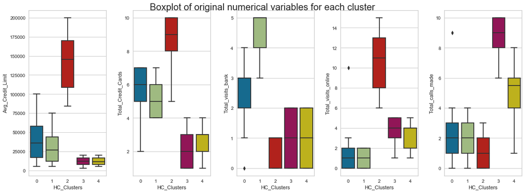

```python
fig, axes = plt.subplots(1, 5, figsize=(16, 6))
fig.suptitle("Boxplot of original numerical variables for each cluster", fontsize=20)
counter = 0
for ii in range(5):
    sns.boxplot(ax=axes[ii], y=df1[num_col[counter]], x=df1["HC_Clusters"])
    counter = counter + 1

fig.tight_layout(pad=2.0)
```

## Insights

- **Clusters 0**:
  - There are 194 customers in this cluster
  - The Avg_Credit_limit for this cluster is roughly 37,600 which is way above the median limit
  - Customers in this cluster have approximately 6 credit cards
  - 3 visits were made by these customers to the bank in a year
  - Roughly 1 visit was made online by customers in this cluster in a year
  - Customers in this cluster made 2 calls to the customer service of the bank in a year
- **Cluster 1**:
  - There are 186 customers in this cluster
  - The Avg_Credit_limit for this cluster is roughly 30,500 which is way above the median limit
  - Customers in this cluster have approximately 5 credit cards
  - 4 visits were made by these customers to the bank in a year
  - 1 visit was made online by customers in this cluster in a year
  - Customers in this cluster made 2 calls to the customer service of the bank in a year
- **Cluster 2**:
  - There are 50 customers in this cluster
  - The Avg_Credit_limit for this cluster is roughly 141,000 which is way above the 75th percentile limit
  - Customers in this cluster have approximately 9 credit cards
  - 1 visit was made by these customers to the bank in a year
  - Roughly 11 visit were made online by customers in this cluster in a year
  - Customers in this cluster made 1 call to the customer service of the bank in a year
- **Cluster 3**:
  - There are 101 customers in this cluster
  - The Avg_Credit_limit for this cluster is roughly 12,200 which is way below the median limit
  - Customers in this cluster have approximately 2 credit cards
  - 1 visit was made by these customers to the bank in a year
  - Roughly 4 visits were made online by customers in this cluster in a year
  - Customers in this cluster made approx. 9 calls to the customer service of the bank in a year
- **Cluster 4**:
  - There are 118 customers in this cluster
  - The Avg_Credit_limit for this cluster is roughly 12,000 which is way below the median limit
  - Customers in this cluster have approximately 3 credit cards
  - 1 visit was made by these customers to the bank in a year
  - Roughly 3 visits were made online by customers in this cluster in a year
  - Customers in this cluster made approx. 5 calls to the customer service of the bank in a year

### Cluster Algorithm Comparison

**K-Means Clustering Algorithm**

- This algorithm gave the best Clusters at k=4 i.e 4 Clusters
- Cluster 3 returned the population of customers with the highest Avg_Credit_Limit with 50 customers and the highest Total_Credit_Cards of roughly 9 as well as 11 Total_Online_visits
- Cluster 1 captures the number of customers with the highest number of Total_visits_bank at approximately 5 with 185 customers
- Cluster 2 returned the highest Total_calls_made at approximately 7 and a total of 218 customers being the highest in across the distribution
- Cluster 0 seems quite unique as it returns the next highest population in the distribution as well as the in value of the Avg_Credit_Limits and probably speaks to the mid-executives, Senior managers or Startup/SME Entreprenuers
- Finally, computational time was faster

**Agglomerative(Heirachichal) Clustering Algorithm**